# Brauchle_HW7

Natascha Brauchle

April 3, 2019

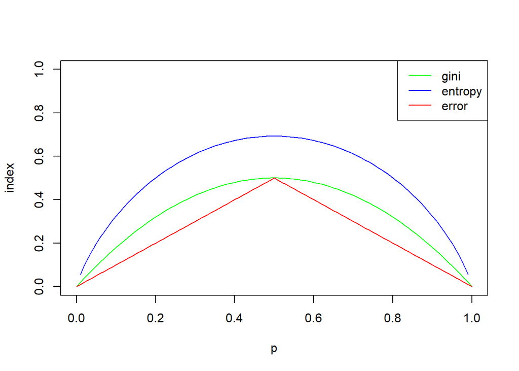

```r
#3
p <- seq(0, 1, 0.01)
gini <- 2*p*(1-p)
entropy <- -(p*log(p) + (1-p)*log(1-p))
error <- 1 - pmax(p, 1-p)

plot(NA, NA, xlim = c(0,1), ylim = c(0,1), xlab = 'p', ylab = 'index')
lines(p, gini, type = 'l', col = "green")
lines(p, entropy, col = 'blue')
lines(p, error, col = 'red')
legend(x= "topright", legend = c("gini", "entropy", "error"), col = c("green", "blue", "red" ), lty =1)
```

3. Entropy MSE is always the largest, followed by gini, and then followed by classification error. They are maximized when p = 0.5.

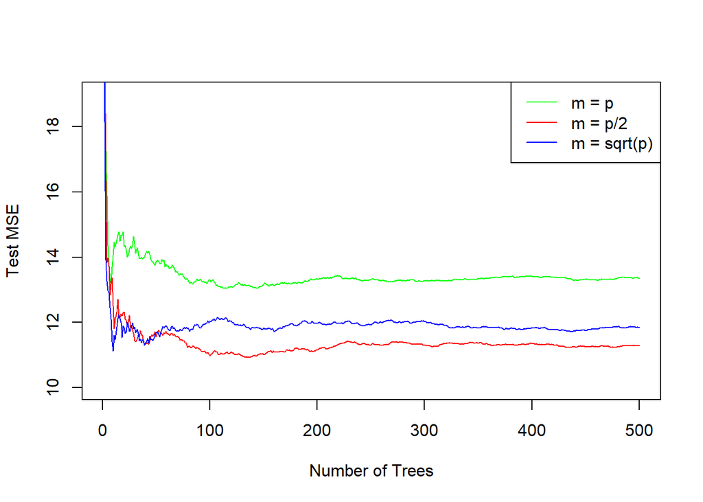

```r
#7
set.seed(1)
np <- ncol(Boston) - 1

sample_set <- sample(1:nrow(Boston), nrow(Boston) / 2)
Boston.train <- Boston[sample_set, -14]
Boston.test <- Boston[-sample_set, -14]
Y.train <- Boston[sample_set, 14]
Y.test <- Boston[-sample_set, 14]

mse <- matrix(nrow = 500)
mtry_set <- c(np, np/2, sqrt(np))
for (i in mtry_set){
  rf.boston <- randomForest(Boston.train, y = Y.train, xtest = Boston.test, ytest = Y.test, mtry = i, ntree = 500)
  mse_loop <- rf.boston$test$mse
  mse <- cbind(mse, mse_loop)
}

plot(1:500, mse[,2], col = "green", type = "l", xlab = "Number of Trees", ylab = "Test MSE", ylim = c(10,19))
lines(1:500, mse[,3], col = "red", type = "l")
lines(1:500, mse[,4], col = "blue", type = "l")
legend("topright", c("m = p", "m = p/2", "m = sqrt(p)"), col = c("green", "red", "blue"), cex = 1, lty = 1)
```

```r
#9
#a
set.seed(1)
sample_set <- sample(1:nrow(OJ), 800)
train <- OJ[sample_set,]
test <- OJ[-sample_set,]


#b
library(tree)
tree.OJ = tree(Purchase ~., data = train)
summary(tree.OJ)
```

```
##
## Classification tree:
## tree(formula = Purchase ~ ., data = train)
## Variables actually used in tree construction:
## [1] "LoyalCH"       "PriceDiff"     "SpecialCH"     "ListPriceDiff"
## Number of terminal nodes:  8
## Residual mean deviance:  0.7305 = 578.6 / 792
## Misclassification error rate: 0.165 = 132 / 800
```

9b. The tree has 8 terminal nodes and has a misclassification error rate of 16.5%. The variables used in its construction were: loyalCH, price difference, specialCH, and list price difference.

```r
#c
tree.OJ
```

```
## node), split, n, deviance, yval, (yprob)
##       * denotes terminal node
##
##  1) root 800 1064.00 CH ( 0.61750 0.38250 )
##    2) LoyalCH < 0.508643 350  409.30 MM ( 0.27143 0.72857 )
##      4) LoyalCH < 0.264232 166  122.10 MM ( 0.12048 0.87952 )
##        8) LoyalCH < 0.0356415 57   10.07 MM ( 0.01754 0.98246 ) *
##        9) LoyalCH > 0.0356415 109  100.90 MM ( 0.17431 0.82569 ) *
##      5) LoyalCH > 0.264232 184  248.80 MM ( 0.40761 0.59239 )
##       10) PriceDiff < 0.195 83   91.66 MM ( 0.24096 0.75904 )
##         20) SpecialCH < 0.5 70   60.89 MM ( 0.15714 0.84286 ) *
##         21) SpecialCH > 0.5 13   16.05 CH ( 0.69231 0.30769 ) *
##       11) PriceDiff > 0.195 101  139.20 CH ( 0.54455 0.45545 ) *
##    3) LoyalCH > 0.508643 450  318.10 CH ( 0.88667 0.11333 )
##      6) LoyalCH < 0.764572 172  188.90 CH ( 0.76163 0.23837 )
##       12) ListPriceDiff < 0.235 70   95.61 CH ( 0.57143 0.42857 ) *
##       13) ListPriceDiff > 0.235 102   69.76 CH ( 0.89216 0.10784 ) *
##      7) LoyalCH > 0.764572 278   86.14 CH ( 0.96403 0.03597 ) *
```

9c. Looking at terminal node (8). Starting from the root, LoyalCH was less than 0.508, so we go left. LoyalCH is also less than 0.264, so we go left again. Lastly, LoyalCH is less than 0.0356, so we determine the result is Minute Maid OJ. This branch only used LoyalCH to split the feature space.

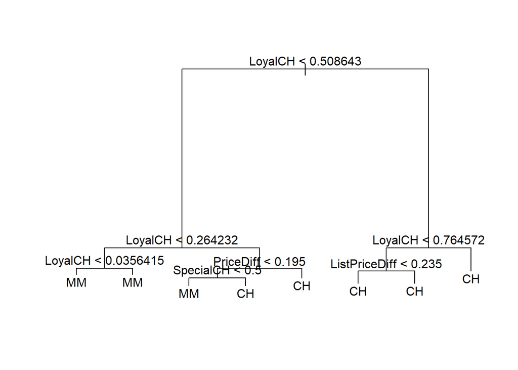

```r
#d
plot(tree.OJ)
text(tree.OJ, pretty = 0)
```

9d. This tree had 7 total branches to end in 8 terminal nodes. It determined 5/8 nodes to be Citrus Hill. LoyalCH appears to be the most important variable to split the feature space as it is used in 4/7 of the splits. Price difference, SpecialCH, and ListPriceDiff were also used.

```r
#e
tree.pred <- predict(tree.OJ, test, type = "class")
table(tree.pred, test$Purchase)
```

```
##
## tree.pred  CH  MM
##        CH 147  49
##        MM  12  62
```

```r
test_error <- (49+12)/(270)
test_error
```

```
## [1] 0.2259259
```

9e. The misclassification error rate was 22.6%.

```r
#9f
cv.OJ <- cv.tree(tree.OJ, FUN = prune.misclass)
cv.OJ
```

```
## $size
## [1] 8 5 2 1
##
## $dev
## [1] 156 156 156 306
##
## $k
## [1]       -Inf   0.000000   4.666667 160.000000
##
## $method
## [1] "misclass"
##
## attr(,"class")
## [1] "prune"         "tree.sequence"
```

9f. The ideal pruned tree size is two trees, as there is no difference between 2, 5, and 8 so we choose the smallest option.

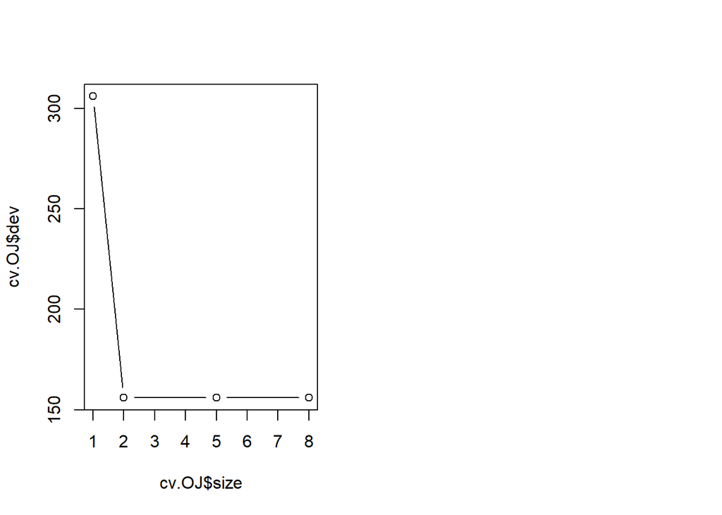

```r
#9g
par(mfrow = c(1,2))
plot(cv.OJ$size, cv.OJ$dev, type = "b")
```

9h. This plot confirms that a tree size of 2 gives us the smallest cross-validated classification error test rate.

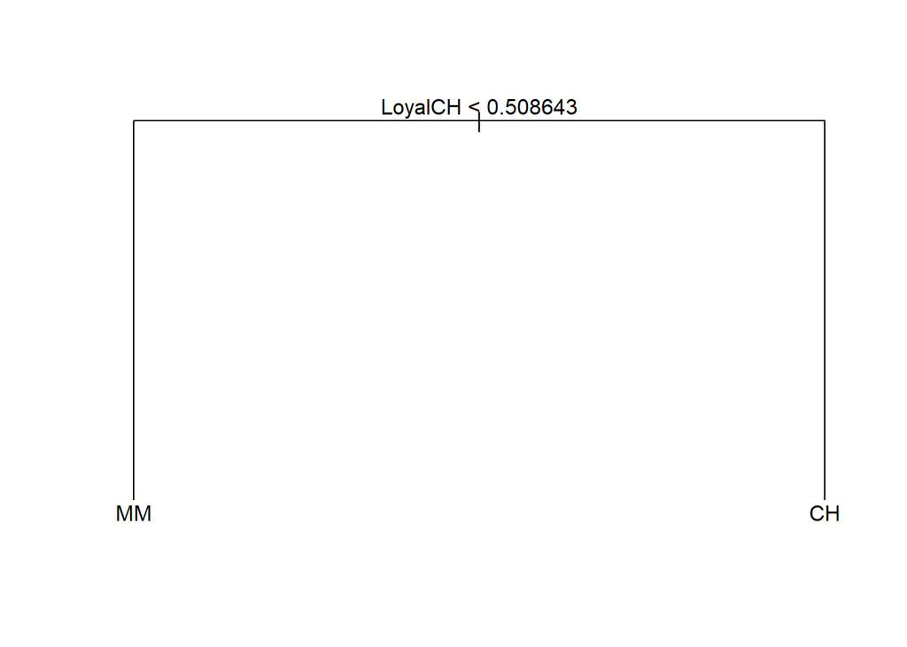

```r
#9i
prune.OJ <- prune.misclass(tree.OJ, best = 2)
plot(prune.OJ)
text(prune.OJ, pretty = 0)
```

9i. This is the pruned tree corresponding to the optimal tree size based on cross-validation. Using purely whether LoyalCH is less than 0.509, we can determine whether a purchased item was Minute Maid or Citrus Hill.

```r
#9j
summary(prune.OJ)
```

```
##
## Classification tree:
## snip.tree(tree = tree.OJ, nodes = 3:2)
## Variables actually used in tree construction:
## [1] "LoyalCH"
## Number of terminal nodes:  2
## Residual mean deviance:  0.9115 = 727.4 / 798
## Misclassification error rate: 0.1825 = 146 / 800
```

```r
summary(tree.OJ)
```

```
##
## Classification tree:
## tree(formula = Purchase ~ ., data = train)
## Variables actually used in tree construction:
## [1] "LoyalCH"       "PriceDiff"     "SpecialCH"     "ListPriceDiff"
## Number of terminal nodes:  8
## Residual mean deviance:  0.7305 = 578.6 / 792
## Misclassification error rate: 0.165 = 132 / 800
```

```r
tree.pred <- predict(tree.OJ, test, type = "class")
table(tree.pred, test$Purchase)
```

```
##
## tree.pred  CH  MM
##        CH 147  49
##        MM  12  62
```

```r
test_error_unprune <- (49+12)/(270)
test_error_unprune
```

```
## [1] 0.2259259
```

```r
tree.pred.prune <- predict(prune.OJ, test, type = "class")
table(tree.pred.prune, test$Purchase)
```

```
##
## tree.pred.prune  CH  MM
##              CH 119  30
##              MM  40  81
```

```r
test_error_prune <- (30+40)/(270)
test_error_prune
```

```
## [1] 0.2592593
```

# 10

```r
library(gbm)
library(dplyr)
```

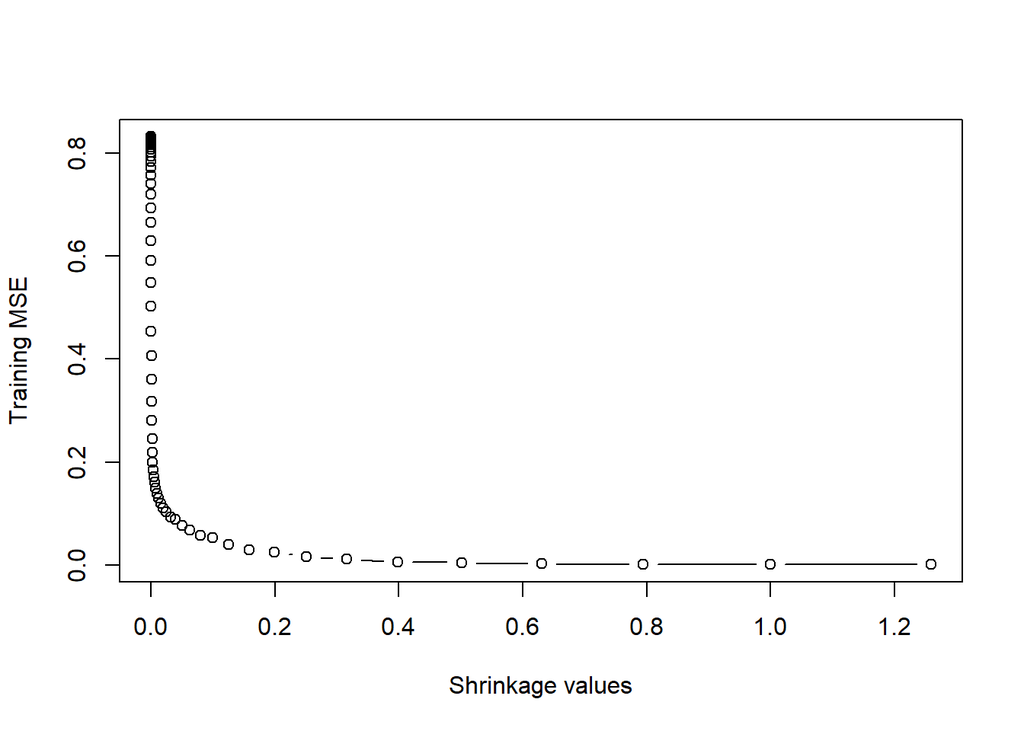

```r
#a
hitters <- Hitters %>% filter(!is.na(Salary)) %>% mutate(Salary = log(Salary))

#b
train_set <- hitters[1:200,]
test_set <- hitters[201:nrow(hitters),]

#c
exp <- seq(-10, 0.1, by = 0.1)
lambda <- 10**exp
train.err <- rep(NA, length(lambda))
for (i in 1:length(lambda)) {
    boost.hitters <- gbm(Salary ~ ., data = train_set, distribution = "gaussian", n.trees = 1000, shrinkage = lambda[i])
    pred.train <- predict(boost.hitters, train_set, n.trees = 1000)
    train.err[i] <- mean((pred.train - train_set$Salary)^2)
}
plot(lambda, train.err, type = "b", xlab = "Shrinkage values", ylab = "Training MSE")
```

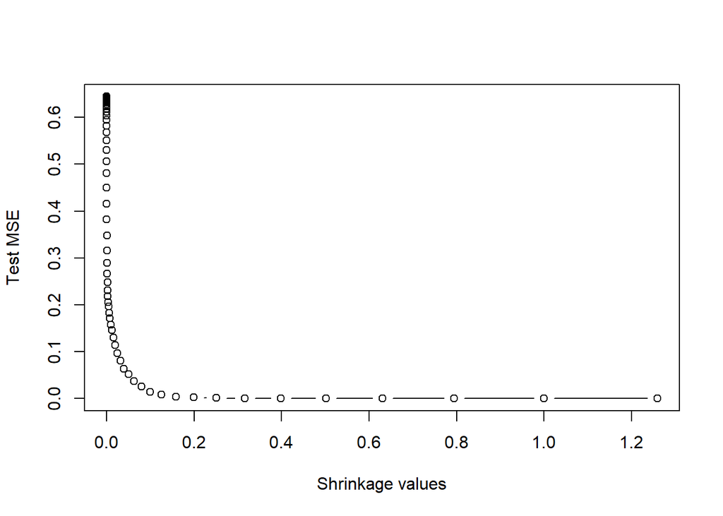

```r
#d
exp <- seq(-8, 0.1, by = 0.1)
lambda <- 10**exp
test.err <- rep(NA, length(lambda))
for (i in 1:length(lambda)) {
    boost.hitters <- gbm(Salary ~ ., data = test_set, distribution = "gaussian", n.trees = 1000, shrinkage = lambda[i])
    pred.test <- predict(boost.hitters, test_set, n.trees = 1000)
    test.err[i] <- mean((pred.test - test_set$Salary)^2)
}
plot(lambda, test.err, type = "b", xlab = "Shrinkage values", ylab = "Test MSE")
```

```r
lambda[which.min(test.err)]
```

```
## [1] 0.7943282
```

```r
#e
boost.hitters <- gbm(Salary ~ ., data = test_set, distribution = "gaussian", n.trees = 1000, shrinkage = 1)
pred.test <- predict(boost.hitters, test_set, n.trees = 1000)
test.err <- mean((pred.test - test_set$Salary)^2)
test.err
```

```
## [1] 1.760441e-08
```

```r
# lasso
library(glmnet)
library(pls)
library(leaps)
```

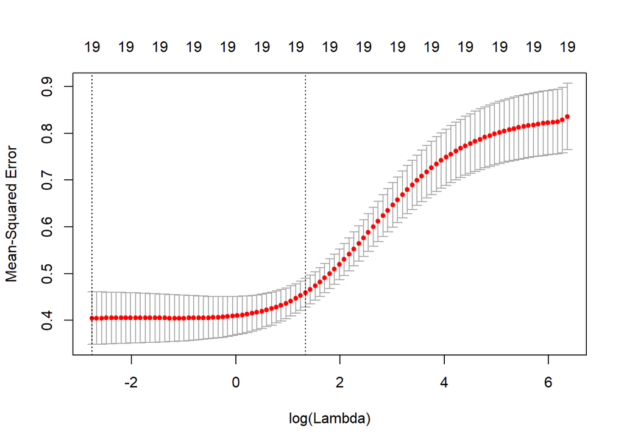

```r
train_matrix = model.matrix(Salary ~., data = train_set)
test_matrix = model.matrix(Salary~ ., data = test_set)
cv.out <- cv.glmnet(train_matrix, train_set$Salary, alpha=0)
plot(cv.out)
```

```r
bestlam = cv.out$lambda.min
bestlam
```

```
## [1] 0.06345943
```

```r
lasso.mod <- glmnet(train_matrix, train_set$Salary, alpha = 1, lambda = bestlam)
lasso.pred <- predict(lasso.mod, s = bestlam, newx = test_matrix)
test.lasso.error <- mean((lasso.pred - test_set$Salary)^2)
test.lasso.error
```

```
## [1] 0.4441547
```

```r
# plain linear regression
lm.1 <- lm(Salary ~ ., data = train_set)
pred.salary <- predict(lm.1, test_set)
test.lm.error<- mean((test_set$Salary - pred.salary)^2)
test.lm.error
```

```
## [1] 0.4917959
```

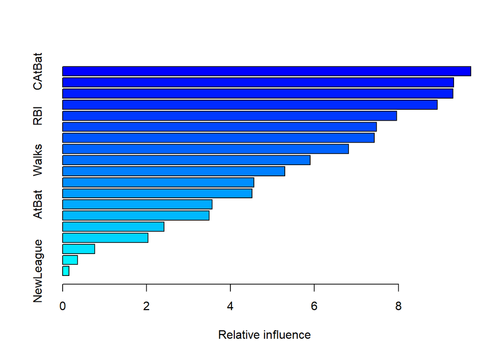

```
##                 var   rel.inf
## CAtBat       CAtBat 9.7263888
## Assists     Assists 9.3217493
## CRuns         CRuns 9.3012255
## Errors       Errors 8.9263851
## RBI             RBI 7.9568021
## CWalks       CWalks 7.4805253
## PutOuts     PutOuts 7.4241123
## Years         Years 6.8128236
## Walks         Walks 5.8976109
## CHits         CHits 5.2953460
## CRBI           CRBI 4.5548844
## Hits           Hits 4.5149740
## AtBat         AtBat 3.5587921
## CHmRun       CHmRun 3.4940069
## HmRun         HmRun 2.4206534
## Division   Division 2.0379465
## League       League 0.7693239
## Runs           Runs 0.3578793
## NewLeague NewLeague 0.1485706
```

```r
#f
summary(boost.hitters)
```

```r
#g
set.seed(1)
p <- ncol(test_set) - 1
bag.hitters <- randomForest(Salary ~., data = train_set, mtry = p, ntree = 500)
yhat.bag <- predict(bag.hitters, newdata = test_set)
mean((yhat.bag - test_set$Salary)^2)
```

```
## [1] 0.2299324
```

10g. The test MSE using bagging was 0.2299.